# GPlately Regional Plots

Lauren Ilano, Hojat Shirmard, Dietmar Muller  
EarthByte Group, School of Geosciences, University of Sydney, NSW 2006, Australia

This notebook generates regional plots using GPlately.

### Data

**📌📌📌 IMPORTANT!!!**

- Mutschler_WorldPorphyryCopperDeposits_GPlates.xlsx
- CarbonateThickness grids (0-170 Ma)
- SedimentThickness grids (0-170 Ma)

**⚠️⚠️⚠️ This notebook will not work without these datasets.**

You can download the datasets at https://repo.gplates.org/webdav/gplately/12-GPlately-Regional-Plots-data.zip (2.3G).

Alternatively, the datasets are also available at https://zenodo.org/records/13777155.

This notebook requires several dependencies. The easiest way is to create a Conda environment from [this YAML file](https://github.com/GPlates/gplately/blob/master/docker/env.yaml). Otherwise, make sure all required dependencies are installed before running the notebook.

```python
import warnings, os
os.environ["GPLATELY_DISABLE_DEV_WARNING"] = "true"
import gplately
from pathlib import Path
import matplotlib.pyplot as plt
import cartopy.crs as ccrs
import numpy as np
import pandas as pd
from IPython.display import clear_output

# Need joblib to run the script on multiple cores, and moviepy to make the movies
from joblib import Parallel, delayed
try:
    from moviepy.editor import ImageSequenceClip  # moviepy 1.x
except ImportError:
    from moviepy import ImageSequenceClip  # moviepy 2.x


# Plotting dependencies
from cmcrameri import cm

warnings.filterwarnings("ignore", category=UserWarning)
warnings.filterwarnings("ignore", category=RuntimeWarning)
warnings.filterwarnings("ignore", category=FutureWarning)

data_dir = Path("WorkflowData/12-GPlately-Regional-Plots")
output_dir = data_dir / "output"
output_dir.mkdir(parents=True, exist_ok=True)
source_data_dir = "12-GPlately-Regional-Plots-Source-Data"

# This workflow takes long time to finish. For a quick run, set the environment variable flag GPLATELY_NOTEBOOK_QUICK_RUN to true
if gplately.settings.notebook_quick_run:
    quick_run = True
else:
    quick_run = False

if not quick_run:
    time_steps = np.arange(170, -1, -1)
else:
    # This notebook takes a long time to run. For a quick run, we can plot every 34 million years (170, 136, 102, 68, 34, 0)
    time_steps = np.arange(170, -1, -34)
```

```
Matplotlib is building the font cache; this may take a moment.
```

Check whether the required datasets are available in the expected directory before continuing.

```python
deposits_file = f"{source_data_dir}/Mutschler_WorldPorphyryCopperDeposits_GPlates.xlsx"
# Template paths to the sediment thickness and carbonate sediment thickness grid
# files, with the reconstruction time filled in later via .format()
total_sed_grid_filename = f"{source_data_dir}/SedimentThickness/sed_thick_0.1d_{{}}.nc"
carbonate_sed_grid_filename = f"{source_data_dir}/CarbonateThickness/uncompacted_carbonate_thickness_{{}}Ma.nc"
try:
    if not os.path.exists(deposits_file):
        raise FileNotFoundError(f"Deposits file not found: {deposits_file}")
    for time in time_steps:
        if not os.path.exists(total_sed_grid_filename.format(time)):
            raise FileNotFoundError(f"Total sediment grid file not found: {total_sed_grid_filename.format(time)}")
        if not os.path.exists(carbonate_sed_grid_filename.format(time)):
            raise FileNotFoundError(f"Carbonate sediment grid file not found: {carbonate_sed_grid_filename.format(time)}")
except FileNotFoundError as e:
    print(e)
    print("Please ensure that the required data files are present in the source_data directory.")
    print("You can download the data at https://repo.gplates.org/webdav/gplately/12-GPlately-Regional-Plots-data.zip (2.3G).")
    raise
```

```python
pmm_model = gplately.PlateModelManager().get_model(
    "Alfonso2024",  # model name
    data_dir="plate-model-repo",  # the folder to save the model files
)
assert pmm_model is not None, "Failed to load the plate model"
model = gplately.PlateReconstruction(
    pmm_model.get_rotation_model(),
    topology_features=pmm_model.get_layer("Topologies"),
    static_polygons=pmm_model.get_layer("StaticPolygons"),
)

gplot = gplately.PlotTopologies(
    model,
    coastlines=pmm_model.get_layer("Coastlines"),
    time=170,
)
```

# Load deposits

Point to the location of your deposits (.xlsx) file — running this cell will generate a `pandas` DataFrame containing the deposit coordinates.

```python
# Load the Excel file
df = pd.read_excel(deposits_file, sheet_name="Deposits")

# Clean column names
df.columns = df.columns.str.strip().str.replace(" ", "_").str.replace("–", "-")

# Rename odd characters if present
df.rename(
    columns={
        "Au_grade_gPERt": "Au_grade",
        "Ag_grade_gPERt": "Ag_grade",
        "w’W_mt": "W_mt",
    },
    inplace=True,
)

# Keep only relevant columns
columns_to_keep = [
    "Camp",
    "Lat_Dec",
    "Long_Dec",
    "AGE",
    "Type",
    "Ore_mt",
    "Cu_mt",
    "Mo_mt",
    "Au_kg",
    "Ag_kg",
    "Cu_grade",
    "Mo_grade",
    "Au_grade",
    "Ag_grade",
]
df = df[columns_to_keep]

# Filter to Porphyry deposits (case-insensitive)
df = df[df["Type"].str.contains("Porphyry", case=False, na=False)]

# Rename coordinate columns
df.rename(columns={"Lat_Dec": "LAT", "Long_Dec": "LON"}, inplace=True)

# Convert AGE and Cu_mt to numeric
df["Cu_mt"] = pd.to_numeric(df["Cu_mt"], errors="coerce")
df["AGE"] = pd.to_numeric(df["AGE"], errors="coerce")

# Filter out invalid or missing data
df = df.dropna(subset=["Cu_mt", "AGE"])
df = df[df["Cu_mt"] > 0]

# Filter deposits with AGE <= 171 Ma (keeps ages up to and just beyond 170 Ma)
df = df[df["AGE"] <= 171]

# Define custom bins and labels
custom_bins = [0, 2e6, 10e6, 30e6, np.inf]
custom_labels = [
    "Minor (<2 Mt)",
    "Moderate (2-10 Mt)",
    "Major (10-30 Mt)",
    "Giant (>30 Mt)",
]

# Categorize SIZE
df["SIZE"] = pd.cut(
    df["Cu_mt"], bins=custom_bins, labels=custom_labels, include_lowest=True
)

# Show distribution
print(df["SIZE"].value_counts())
```

```
SIZE
Minor (<2 Mt)         80
Moderate (2-10 Mt)    64
Major (10-30 Mt)      13
Giant (>30 Mt)         7
Name: count, dtype: int64
```

```python
def plot_deposits(time, extents, proj, grid_type, save_fig=None):
    """Plot categorized copper deposits on a reconstructed map, with Cu grade shown by colour and deposit size shown by symbol size."""
    warnings.filterwarnings("ignore", category=UserWarning)
    warnings.filterwarnings("ignore", category=RuntimeWarning)
    warnings.filterwarnings("ignore", category=FutureWarning)

    gplot.time = time

    fig = plt.figure(figsize=(14, 10))
    ax1 = fig.add_subplot(111, projection=proj)
    cmap = cm.batlow_r # type: ignore

    # Load grid
    if grid_type.lower() == "total":
        grid_filename = total_sed_grid_filename
        vmin, vmax = 50, 400
        grid_label = "Sediment thickness (m)"
    elif grid_type.lower() == "carbonate":
        grid_filename = carbonate_sed_grid_filename
        vmin, vmax = 0, 500
        grid_label = "Carbonate sediment thickness (m)"
    else:
        raise ValueError(f"Grid type '{grid_type}' is not supported.")

    im = gplot.plot_grid_from_netCDF(
        ax1, grid_filename.format(int(gplot.time)), cmap=cmap, vmin=vmin, vmax=vmax
    )

    # Plot tectonic features
    gplot.plot_coastlines(ax1, facecolor="silver", edgecolor="None")
    gplot.plot_all_topological_sections(ax1, color="grey", tessellate_degrees=1)
    gplot.plot_ridges(ax1, color="darkred", linewidth=2, tessellate_degrees=1)
    gplot.plot_trenches(ax1, color="white", linewidth=5, tessellate_degrees=1)
    gplot.plot_trenches(ax1, color="k", tessellate_degrees=1)
    gplot.plot_subduction_teeth(ax1, color="k", spacing=0.02, zorder=10)
    gplot.plot_plate_motion_vectors(
        ax1, spacingX=10, spacingY=10, normalise=True, zorder=10, alpha=0.5
    )

    ax1.set_extent(extents, ccrs.PlateCarree())  # type: ignore

    # Cu grade bins (in %), reversed color order
    cu_bins = [0, 0.3, 0.6, 1.0, float("inf")]
    cu_labels = [
        "Low (<0.3%)",
        "Moderate (0.3-0.6%)",
        "High (0.6-1.0%)",
        "Very High (>1.0%)",
    ]
    cu_colors = ["blue", "green", "orange", "red"]  # reversed order

    # New Size categories (renamed labels)
    size_styles = {
        "Small (<2 Mt)": {"size": 70},
        "Medium (2-10 Mt)": {"size": 100},
        "Large (10-30 Mt)": {"size": 130},
        "Giant (>30 Mt)": {"size": 170},
    }

    # Filter and classify deposits
    cu_df = df[
        (df["AGE"] != "Unknown") & (df["AGE"] >= time) & df["Cu_grade"].notna()
    ].copy()
    cu_df["Cu_grade_%"] = cu_df["Cu_grade"] * 100  # Convert to percent
    cu_df["Cu_bin"] = pd.cut(
        cu_df["Cu_grade_%"], bins=cu_bins, labels=cu_labels, include_lowest=True
    )

    # Replace size label column if needed (optional, based on your data)
    size_map = {
        "Minor (<2 Mt)": "Small (<2 Mt)",
        "Moderate (2-10 Mt)": "Medium (2-10 Mt)",
        "Major (10-30 Mt)": "Large (10-30 Mt)",
        "Giant (>30 Mt)": "Giant (>30 Mt)",
    }
    cu_df["SIZE"] = cu_df["SIZE"].astype("string").replace(size_map)

    # Plot deposits: by Cu bin (color) and SIZE (size)
    for cu_label, cu_color in zip(cu_labels, cu_colors):
        for size_label, style in size_styles.items():
            subset = cu_df[
                (cu_df["Cu_bin"] == cu_label) & (cu_df["SIZE"] == size_label)
            ]
            if subset.empty:
                continue
            points = gplately.Points(
                model, subset["LON"].to_numpy(), subset["LAT"].to_numpy()
            )
            lons, lats = points.reconstruct(time, return_array=True)  # type: ignore
            ax1.scatter(
                lons,  # type: ignore
                lats,  # type: ignore
                marker="o",
                color=cu_color,
                edgecolors="black",
                linewidths=0.2,
                alpha=0.7,
                s=style["size"],
                transform=ccrs.PlateCarree(),
            )

    # Legends
    from matplotlib.lines import Line2D

    # Cu Grade Legend (color)
    cu_legend_elements = [
        Line2D(
            [0],
            [0],
            marker="o",
            color=color,
            label=label,
            markersize=10,
            linestyle="",
            markeredgecolor="black",
            alpha=0.7,
        )
        for label, color in zip(cu_labels, cu_colors)
    ]
    # legend1 = ax1.legend(handles=cu_legend_elements, title="Cu Grade (%)",
    #                      loc='upper left', bbox_to_anchor=(0, 1), fontsize=10, title_fontsize=11)

    # Deposit Size Legend (size)
    size_legend_elements = [
        Line2D(
            [0],
            [0],
            marker="o",
            color="gray",
            label=label,
            markersize=style["size"] * 0.05,
            linestyle="",
            alpha=0.7,
            markeredgecolor="black",
        )
        for label, style in size_styles.items()
    ]

    # legend2 = ax1.legend(handles=size_legend_elements, title="Deposit Size (Mt)",
    #                      loc='lower left', bbox_to_anchor=(0, 0), fontsize=10, title_fontsize=11)

    legend1 = ax1.legend(
        handles=cu_legend_elements,
        title="Cu Grade (%)",
        loc="upper left",
        bbox_to_anchor=(0, 1),
        fontsize=10,
        title_fontsize=11,
        framealpha=1,  # fully opaque
        facecolor="white",  # background color
        edgecolor="black",  # optional: border color
    )

    legend2 = ax1.legend(
        handles=size_legend_elements,
        title="Deposit Size (Mt)",
        loc="lower left",
        bbox_to_anchor=(0, 0),
        fontsize=10,
        title_fontsize=11,
        framealpha=1,  # fully opaque
        facecolor="white",  # background color
        edgecolor="black",  # optional: border color
    )
    legend1.set_zorder(100)
    legend2.set_zorder(100)

    # Add both legends to the plot
    ax1.add_artist(legend1)
    ax1.add_artist(legend2)

    # Final touches
    # latlonticks(ax1)
    gl = ax1.gridlines(  # type: ignore
        draw_labels=False, linewidth=0.5, color="gray", alpha=0.7, linestyle="--"
    )
    gl.top_labels = False
    gl.right_labels = False
    gl.bottom_labels = True
    gl.left_labels = True
    gl.xlabel_style = {"size": 10}
    gl.ylabel_style = {"size": 10}

    plt.title(f"{int(gplot.time)} Ma", fontsize=20)
    cbar = plt.colorbar(im, shrink=0.5)
    cbar.set_label(grid_label, fontsize=14)

    if save_fig:
        fig.savefig(save_fig, dpi=300, bbox_inches="tight")
    else:
        plt.show()
    plt.close()
```

# North America

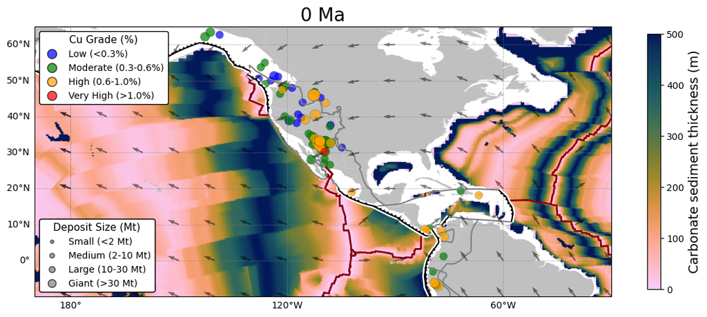

```python
plot_deposits(
    0,
    extents=(-190, -30, -10, 65),
    proj=ccrs.PlateCarree(float(np.mean((-190, -30)))),
    grid_type="carbonate",
)
```

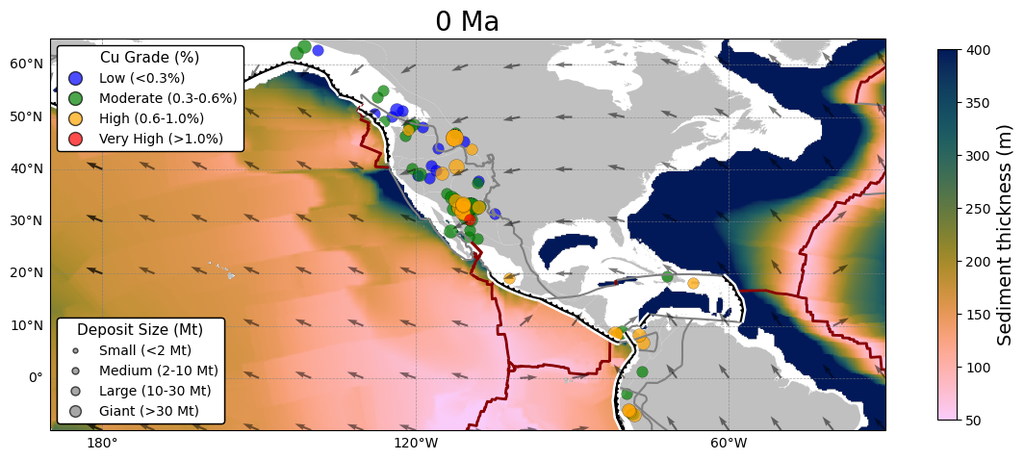

```python
plot_deposits(
    0,
    extents=(-190, -30, -10, 65),
    proj=ccrs.PlateCarree(float(np.mean((-190, -30)))),
    grid_type="total",
)
```

## Generating Plots (png)

This code generates and saves geological deposit plots for different times and grid types, either sequentially or in parallel depending on the `use_parallel` flag.

```python
use_parallel = True

n_jobs = -2 # if this code cell crashes, try setting n_jobs to a smaller number (e.g., 2 or 4) to limit the number of parallel processes.
# Alternatively, you can increase the memory allocated to Docker with `--memory=24g` when starting the Docker container.
# For details, see https://gplates.github.io/gplately/latest/sphinx/html/faq.html
grid_types = ["carbonate", "total"]
if use_parallel:
    for grid_type in grid_types:
        # Use LokyBackend to protect the netCDF routine
        slabdip_img = Parallel(n_jobs=n_jobs, backend="loky", verbose=1)(
            delayed(plot_deposits)(
                reconstruction_time,
                extents=(-190, -30, -10, 65),
                proj=ccrs.PlateCarree(float(np.mean((-190, -30)))),
                grid_type=grid_type,
                save_fig=f"{output_dir}/NorthAmerica_{grid_type}_{reconstruction_time}.png"
            )
            for reconstruction_time in time_steps
        )
else:
    for grid_type in grid_types:
        for reconstruction_time in time_steps:
            plot_deposits(
                reconstruction_time,
                extents=(-190, -30, -10, 65),
                proj=ccrs.PlateCarree(float(np.mean((-190, -30)))),
                grid_type=grid_type,
                save_fig=f"{output_dir}/NorthAmerica_{grid_type}_{reconstruction_time}.png"
                )

            print(f"Finished plotting {reconstruction_time} Ma")
clear_output()
```

## Generating Movies (mp4) from Plots (png)

```python
for grid_type in grid_types:
    frame_list = []
    for time in time_steps:
        frame_list.append(
            f"{output_dir}/NorthAmerica_{grid_type}_{time}.png"
        )

    clip = ImageSequenceClip(frame_list, fps=25)

    clip.write_videofile(
        f"{output_dir}/NorthAmerica_{grid_type}.mp4",
        fps=25,
        codec="libx264",
        bitrate="5000k",
        audio=False,
        logger=None,
        ffmpeg_params=[
            "-vf",
            "pad=ceil(iw/2)*2:ceil(ih/2)*2",
            "-pix_fmt",
            "yuv420p",
        ],
    )
    print(f"The video file has been saved to {output_dir}/NorthAmerica_{grid_type}.mp4")
```

```
The video file has been saved to WorkflowData/12-GPlately-Regional-Plots/output/NorthAmerica_carbonate.mp4
```

```
The video file has been saved to WorkflowData/12-GPlately-Regional-Plots/output/NorthAmerica_total.mp4
```

# East Asia

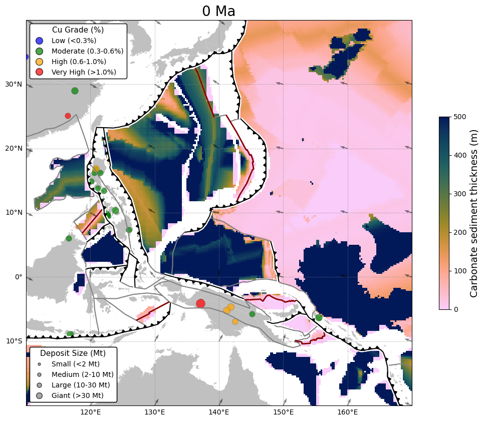

```python
plot_deposits(
    0,
    extents=(110, 170, -20, 40),
    proj=ccrs.PlateCarree(float(np.mean((120, 40)))),
    grid_type="carbonate",
)
```

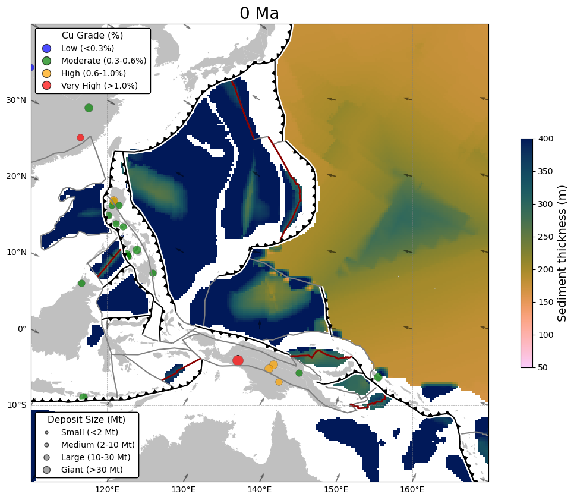

```python
plot_deposits(
    0,
    extents=(110, 170, -20, 40),
    proj=ccrs.PlateCarree(float(np.mean((120, 40)))),
    grid_type="total",
)
```

## Generating Plots (png)

This code generates and saves geological deposit plots for different times and grid types, either sequentially or in parallel depending on the `use_parallel` flag.

```python
use_parallel = True

n_jobs = -2 # if this code cell crashes, try setting n_jobs to a smaller number (e.g., 2 or 4) to limit the number of parallel processes.
# Alternatively, you can increase the memory allocated to Docker with `--memory=24g` when starting the Docker container.
# For details, see https://gplates.github.io/gplately/latest/sphinx/html/faq.html
grid_types = ["carbonate", "total"]
if use_parallel:
    for grid_type in grid_types:
        # Use LokyBackend to protect the netCDF routine
        slabdip_img = Parallel(n_jobs=n_jobs, backend="loky", verbose=1)(
            delayed(plot_deposits)(
                reconstruction_time,
                extents=(110, 170, -20, 40),
                proj=ccrs.PlateCarree(float(np.mean((120, 40)))),
                grid_type=grid_type,
                save_fig=f"{output_dir}/EastAsia_{grid_type}_{reconstruction_time}.png",
            )
            for reconstruction_time in time_steps
        )
else:
    for grid_type in grid_types:
        for reconstruction_time in time_steps:
            plot_deposits(
                reconstruction_time,
                extents=(110, 170, -20, 40),
                proj=ccrs.PlateCarree(float(np.mean((120, 40)))),
                grid_type=grid_type,
                save_fig=f"{output_dir}/EastAsia_{grid_type}_{reconstruction_time}.png",
            )
            print(f"Finished plotting {reconstruction_time} Ma")
clear_output()
```

## Generating Movies (mp4) from Plots (png)

```python
for grid_type in grid_types:
    frame_list = []
    for time in time_steps:
        frame_list.append(
            f"{output_dir}/EastAsia_{grid_type}_{time}.png"
        )

    clip = ImageSequenceClip(frame_list, fps=25)

    clip.write_videofile(
        f"{output_dir}/EastAsia_{grid_type}.mp4",
        fps=25,
        codec="libx264",
        bitrate="5000k",
        audio=False,
        logger=None,
        ffmpeg_params=[
            "-vf",
            "pad=ceil(iw/2)*2:ceil(ih/2)*2",
            "-pix_fmt",
            "yuv420p",
        ],
    )
    print(f"The video file has been saved to {output_dir}/EastAsia_{grid_type}.mp4")
```

```
The video file has been saved to WorkflowData/12-GPlately-Regional-Plots/output/EastAsia_carbonate.mp4
```

```
The video file has been saved to WorkflowData/12-GPlately-Regional-Plots/output/EastAsia_total.mp4
```

Generate plots and movies for other regions by updating the `extents` values in the **Generating Plots (png)** and **Generating Movies (mp4) from Plots (png)** sections—for example:

- **South America:** `extents = (-120, -30, -60, 5)`
- **Mediterranean Sea:** `extents = (0, 70, 10, 60)`